# Hong Qian (钱宏)

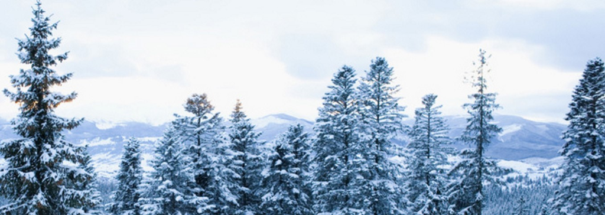

## Contact

Research and Collections Center

Illinois State Museum

1011 East Ash Street

Springfield, IL 62703, USA

Phone: (217) 782-2621, Fax: (217) 785-2857

Email: hong.qian@illinoisstatemuseum.org

## Education

- Ph.D. (Biogeography), University of British Columbia, Canada
- Ph.D. (Ecology), Institute of Applied Ecology, Chinese Academy of Sciences, China
- M.Sc. (Botany), Anhui Agricultural University, China
- B.Sc. (Forest Science), Anhui Agricultural University, China

## Research Interests

His research interest lies at the interface of ecology and biogeography, and involves a wide range of spatial scales from local to global and a variety of taxa including bryophytes, vascular plants, vertebrates, and invertebrates. In particular, He is interested in finding out the relative roles of historical and contemporary factors in determining global patterns in biodiversity.

## Publications

[*ORCID: 0000-0002-1381-7496*](http://orcid.org/0000-0002-1381-7496)

Hong Qian was the first author on **131** of the 170 publications listed below.

Please go to [*ResearchGate*](https://www.researchgate.net/profile/Hong-Qian-6/publications) for PDF reprints.

1. **Qian, H.** 2023. Global patterns of phylogenetic relatedness of invasive flowering plants. *Diversity and Distributions* 29: 1106–1117. [https://doi.org/10.1111/ddi.13745]
2. **Qian, H.** and B. Sandel. 2023. The role of phylogenetic relatedness on success of non-native plants crossing the naturalization–invasion transition in North America. *Ecography* 2023: e06750. [https://doi.org/10.1111/ecog.06750]
3. **Qian, H.** and T. Deng. 2023. Geographic patterns and climatic correlates of deep evolutionary legacies for angiosperm assemblages in China. *Journal of Systematics and Evolution* 61: 563-571. [http://doi.org/10.1111/jse.12856]
4. **Qian, H.**, M. Kessler, J. Zhang, Y. Jin, and M. Jiang. 2023. Global patterns and climatic determinants of phylogenetic structure of regional fern floras. *New Phytologist* 239: 415–428. [https://doi.org/10.1111/nph.18920]
5. **Qian, H.**, J. Zhang, Y. Jin, and T. Deng. 2023. Effects of evolutionary history on assembly of flowering plants in regions across Africa. *Ecography* 2023: e06775. [https://doi.org/10.1111/ecog.06775]
6. Guo, Q., **H. Qian**, and J. Zhang. 2023. Does regional species diversity resist biotic invasions? *Plant Diversity* 45: 353-357. [https://doi.org/10.1016/j.pld.2022.09.004]
7. Jin, Y. and **H. Qian**. 2023. U.PhyloMaker: An R package that can generate large phylogenetic trees for plants and animals. *Plant Diversity* 45: 347–352. [https://doi.org/10.1016/j.pld.2022.12.007]
8. **Qian, H.**, J. Zhang, and M. Jiang. 2023. Global patterns of taxonomic and phylogenetic diversity of flowering plants: Biodiversity hotspots and coldspots. *Plant Diversity* 45: 265–271. [https://doi.org/10.1016/j.pld.2023.01.009]
9. Huang, X., F. Li, Z. Wang, Y. Jin, and **H. Qian**. 2023. Are allometric model parameters of aboveground biomass for trees phylogenetically constrained? *Plant Diversity* 45: 229-233. [https://doi.org/10.1016/j.pld.2022.11.005]
10. Zhou, Y.-D., **H. Qian**, Y. Jin, X. Yan, and Q.-F. Wang. 2023. Geographic patterns of taxonomic and phylogenetic β-diversity of aquatic angiosperms in China. *Plant Diversity* 45: 177-184. [https://doi.org/10.1016/j.pld.2022.12.006]
11. **Qian, H.** 2023. Patterns of phylogenetic relatedness of non-native plants across the introduction–naturalization–invasion continuum in China. *Plant Diversity* 45: 169-176. [https://doi.org/10.1016/j.pld.2022.12.005]
12. Zhang, J., and **H. Qian**. 2023. U.Taxonstand: An R package for standardizing scientific names of plants and animals. *Plant Diversity* 45, 1–5. [https://doi.org/10.1016/j.pld.2022.09.001]
13. **Qian, H.**, C. Chu, D. Li, Y. Cao, B. Sandel, M.U.M. Anas, and N.E. Mandrak. 2023. Effects of non-native species on phylogenetic dispersion of freshwater fish communities in North America. *Diversity and Distributions* 29: 143–156. [https://doi.org/10.1111/ddi.13647]
14. **Qian, H.**, M. Kessler, and Y. Jin. 2023. Spatial patterns and climatic drivers of phylogenetic structure for ferns along the longest elevational gradient in the world. *Ecography* 2023: e06516. [http://doi.org/10.1111/ecog.06516]
15. Fu, Q., X. Huang, L. Li, Y. Jin, **H. Qian**, X. Kuai, Y. Ye, H. Wang, T.Deng, and H. Sun. 2022. Linking evolutionary history to species extinction for flowering plants in global biodiversity hotspots. *Diversity and Distributions* 28: 2871–2885. [http://doi.org/10.1111/ddi.13603]
16. Li, L., X. Xu, **H. Qian**, X. Huang, P. Liu, J.B. Landis, Q. Fu, L. Sun, H. Wang, T. Deng, and H. Sun. 2022. Elevational patterns of phylogenetic structure of angiosperms in a biodiversity hotspot in eastern Himalaya. *Diversity and Distributions* 28: 2534–2548. [http://doi.org/10.1111/ddi.13513]
17. Guo, Q., **H. Qian**, and J. Zhang. 2022. On the relationship between species diversity and range size. *Journal of Biogeography* 49: 1911-1919. [http://doi.org/10.1111/jbi.14477]
18. **Qian, H.**, and S. Qian. 2022. Floristic homogenization as a result of the introduction of exotic species in China. *Diversity and Distributions* 28: 2139-2151. [http://doi.org/10.1111/ddi.13612]
19. **Qian, H.**, M. Rejmánek, and S. Qian. 2022. Are invasive species a phylogenetically clustered subset of naturalized species in regional floras? A case study for flowering plants in China. *Diversity and Distributions* 28: 2084-2093. [http://doi.org/10.1111/ddi.13608]
20. **Qian, H.**, S. Qian, and B. Sandel. 2022. Phylogenetic structure of alien and native species in regional plant assemblages across China: Testing niche conservatism hypothesis versus niche convergence hypothesis. *Global Ecology and Biogeography* 31: 1864-1876. [http://doi.org/10.1111/geb.13566]
21. Jin, Y. and **H. Qian**. 2022. V.PhyloMaker2: An updated and enlarged R package that can generate very large phylogenies for vascular plants. *Plant Diversity* 44: 335-339. [https://doi.org/10.1016/j.pld.2022.05.005]
22. **Qian, H.**, J. Zhang, and J. Zhao. 2022. How many known vascular plant species are there in the world? An integration of multiple global plant databases. *Biodiversity Science* 30: 22254 [https://www.biodiversity-science.net/fileup/1005-0094/SUPPL/supplFile_art_20220723120220.pdf] **钱宏**，张健，赵静超. 2022. 世界上已知维管植物有多少种？基于多个全球植物数据库的整合. *生物多样性* 30: 22254 [https://www.biodiversity-science.net/CN/10.17520/biods.2022254]
23. **Qian, H.**, M. Kessler, and O.R. Vetaas. 2022. Pteridophyte species richness in the central Himalaya is limited by cold climate extremes at high elevations, and rainfall seasonality at low elevations. *Ecology and Evolution* 12: e8958. [https://doi.org/10.1002/ece3.8958]
24. **Qian, H.**, F. Leprieur, Y. Jin, X. Wang, and T. Deng. 2022. Influence of phylogenetic scale on the relationships of taxonomic and phylogenetic turnovers with environment for angiosperms in China. *Ecology and Evolution* 12: e8544. [http://doi.org/10.1002/ece3.8544]
25. Zheng, J., Y. Jiang, **H. Qian**, Y. Mao, C. Zhang, X. Tang, Y. Jin, and Y. Yi. 2022. Size-dependent and environment-mediated shifts in leaf traits of a deciduous tree species in a subtropical forest. *Ecology and Evolution* 12: e8516. [https://doi.org/10.1002/ece3.8516]
26. **Qian, H.** and B. Sandel. 2022. Darwin’s preadaptation hypothesis and the phylogenetic structure of native and alien regional plant assemblages across North America. *Global Ecology and Biogeography* 31: 531-545. [https://doi.org/10.1111/geb.13445]
27. **Qian, H.**, T. Deng, and R.E. Ricklefs. 2022. Evolutionary assembly of the Arctic flora. *Global Ecology and Biogeography* 31: 396-404. [https://doi.org/10.1111/geb.13434]
28. **Qian, H.**, J. Zhang, and M.-C. Jiang. 2022. Global patterns of fern species diversity: An evaluation of fern data in GBIF. *Plant Diversity* 44: 135-140. [https://doi.org/10.1016/j.pld.2021.10.001]
29. **Qian, H.**, Y. Zhang, R.E. Ricklefs, and X. Wang. 2022. Relationship of minimum winter temperature and temperature seasonality to the northern range limit and species richness of trees in North America. *Journal of Geographical Sciences* 32: 280-290. [https://doi.org/10.1007/s11442-022-1947-z]
30. **Qian, H.**, and T. Deng. 2021. Geographic patterns and climate correlates of the deviation between phylogenetic and taxonomic diversity for angiosperms in China. *Biological Conservation* 262: 109291. [https://doi.org/10.1016/j.biocon.2021.109291]
31. **Qian, H.**, Y. Zhou, J. Zhang, Y. Jin, T. Deng, and S. Cheng. 2021. A synthesis of botanical informatics for vascular plants in Africa. *Ecological Informatics* 64: 101382. [https://doi.org/10.1016/j.ecoinf.2021.101382]
32. Yin, X., **H. Qian**, X. Sui, M. Zhang, L. Mao, J.-C. Svenning, R.E. Ricklefs, and F. He. 2021. Effects of climate and topography on the diversity anomaly of plants disjunctly distributed in eastern Asia and eastern North America. *Global Ecology and Biogeography* 30: 2029-2042. [https://doi.org/10.1111/geb.13366]
33. Yin, X., S. Jarvie, W.-Y. Guo, T. Deng, L. Mao, M. Zhang, C. Chu, **H. Qian**, J.-C. Svenning, F. He. 2021. Niche overlap and divergence time support niche conservatism in eastern Asia-eastern North America disjunct plants. *Global Ecology and Biogeography* 30: 1990-2003. [https://doi.org/10.1111/geb.13360]
34. **Qian, H.**, Y. Cao, C. Chu, D. Li, B. Sandel, X. Wang, and Y. Jin. 2021. Taxonomic and phylogenetic beta diversity of freshwater fish assemblages in relation to geographic and climatic determinants in North America. *Global Ecology and Biogeography* 30: 1965-1977. [https://doi.org/10.1111/geb.13358]
35. **Qian, H.**, M. Kessler, T. Deng, and Y. Jin. 2021. Patterns and drivers of phylogenetic structure of pteridophytes in China. *Global Ecology and Biogeography* 30: 1835–1846. [https://doi.org/10.1111/geb.13349]
36. **Qian, H.**, R.E. Ricklefs, and W. Thuiller. 2021. Evolutionary assembly of flowering plants into sky islands. *Nature Ecology & Evolution* 5: 640–646. [https://doi.org/10.1038/s41559-021-01423-1]
37. Song, H., A. Ordonez, J.-C. Svenning, **H. Qian**, X. Yin, L. Mao, T. Deng, and J. Zhang. 2021. Regional disparity in extinction risk: comparison of disjunct plant genera between eastern Asia and eastern North America. *Global Change Biology* 27: 1904–1914. [https://doi.org/10.1111/gcb.15525]
38. **Qian, H.**, and Y. Jin. 2021. Are phylogenies resolved at the genus level appropriate for studies on phylogenetic structure of species assemblages? *Plant Diversity* 43: 255–263. [https://doi.org/10.1016/j.pld.2020.11.005]
39. **Qian, H.**, Y. Jin, F. Leprieur, X. Wang, and T. Deng. 2021. Patterns of phylogenetic beta diversity measured at deep evolutionary histories across geographic and ecological spaces for angiosperms in China. *Journal of Biogeography* 48: 773–784. [https://doi.org/10.1111/jbi.14036]
40. **Qian, H.**, Y. Cao, D. Li, C. Chu, B. Sandel, X. Wang. 2020. Geographic patterns and environmental drivers of phylogenetic relatedness and diversity for freshwater fishes in North America. *Ecography* 43: 1814–1824. [https://doi.org/10.1111/ecog.05280]
41. **Qian, H.** 2020. Are species lists derived from modeled species range maps appropriate for macroecological studies? A case study on data from BIEN. *Basic and Applied Ecology* 48: 146–156. [https://doi.org/10.1016/j.baae.2020.08.003]
42. **Qian, H.**, Y. Jin, F. Leprieur, X. Wang, and T. Deng. 2020. Geographic patterns and environmental correlates of taxonomic and phylogenetic beta diversity for large-scale angiosperm assemblages in China. *Ecography* 43: 1706–1716. [https://doi.org/10.1111/ecog.05190]
43. Malanson, G.P., R. Virtanen, A.J. Britton, B. Jiménez-Alfaro, **H. Qian**, A. Petraglia, M. Tomaselli, D. Cooper, C. Damm, R.H. Pemble, R.B. Brett. 2020. Hemispheric- and continental-scale patterns of similarity in mountain tundra. *Annals of the American Association of Geographers* 110: 1005–1021. [http://dx.doi.org/10.1080/24694452.2019.1706990]
44. **Qian, H.**, J. Zhang, B. Sandel, and Y. Jin. 2020. Phylogenetic structure of angiosperm trees in local forest communities along latitudinal and elevational gradients in eastern North America. *Ecography* 43: 419–430. [http://dx.doi.org/10.1111/ecog.04873]
45. Rana, S.K., T.D. Price, and **H. Qian**. 2019. Plant species richness across the Himalaya driven by evolutionary history and current climate. *Ecosphere* 10: Article e02945. [http://dx.doi.org/10.1002/ecs2.2945]
46. **Qian, H.**, T. Deng, Y. Jin, L. Mao, D. Zhao, and R.E. Ricklefs. 2019. Phylogenetic dispersion and diversity in regional assemblages of seed plants in China. *Proceedings of the National Academy of Sciences of the United States of America* 116: 23192–23201. [https://www.pnas.org/cgi/doi/10.1073/pnas.1822153116].
47. **Qian, H.**, B. Sandel, T. Deng, O. R. Vetaas. 2019. Geophysical, evolutionary and ecological processes interact to drive phylogenetic dispersion in angiosperm assemblages along the longest elevational gradient in the world. *Botanical Journal of the Linnean Society* 190: 333–344. [https://doi.org/10.1093/botlinnean/boz030]
48. **Qian, H.** 2019. Biases in assessing the evolutionary history of the angiosperm flora of China. *Journal of Biogeography* 46: 1096-1099. [https://doi.org/10.1111/jbi.13530]
49. Jin, Y. and **H. Qian**. 2019. V.PhyloMaker: an R package that can generate very large phylogenies for vascular plants. *Ecography* 42: 1353-1359. [https://doi.org/10.1111/ecog.04434]
50. **Qian, H.**, T. Deng and H. Sun 2019. Global and regional tree species diversity. *Journal of Plant Ecology* 12: 210–215. [https://doi.org/10.1093/jpe/rty013]
51. **Qian, H.**, T. Deng, J. Beck, H. Sun, C. Xiao, Y. Jin and K.-P. Ma. 2018. Incomplete species lists derived from global and regional specimen-record databases affect macroecological analyses: a case study on the vascular plants of China. *Journal of Biogeography* 45: 2718–2729. [https://doi.org/10.1111/jbi.13462]
52. Field, R. and **H. Qian**. 2018. No empirical evidence to support the hypothesis that daily climate variation has an effect on species’ elevational range size. *Journal of Biogeography* 45: 2827–2836. [https://doi.org/10.1111/jbi.13372]
53. Zhang, J., **H. Qian**, M. Girardello, V. Pellissier, S.E. Nielsen and J.-C. Svenning. 2018. Trophic interactions among vertebrate guilds and plants shape global patterns in species diversity. *Proceedings of the Royal Society B-Biological Sciences* 285: 20180949. [https://doi.org/10.1098/rspb.2018.0949]
54. **Qian, H.** 2018. Climatic correlates of phylogenetic relatedness of woody angiosperms in forest communities along a tropical elevational gradient in South America. *Journal of Plant Ecology* 11: 394–400. [https://doi.org/10.1093/jpe/rtx006]
55. **Qian, H.**, J. Zhang and B.A. Hawkins. 2018. Mean family age of angiosperm tree communities and its climatic correlates along elevational and latitudinal gradients in eastern North America. *Journal of Biogeography* 45: 259–268. [https://doi.org/10.1111/jbi.13108]
56. Deng, T., Y. Chen, H. Wang, X. Zhang, S. Volis, Z. Yusupov, **H. Qian** and H. Sun. 2017. Molecular phylogeny and biogeography of Adenocaulon highlight the biogeographic links between New World and Old World. *Frontiers in Ecology and Evolution* 5: 162. [https://doi.org/10.3389/fevo.2017.00162]
57. **Qian, H.**, Y. Jin and R.E. Ricklefs. 2017. Phylogenetic diversity anomaly in angiosperms between eastern Asia and eastern North America. *Proceedings of the National Academy of Sciences of the United States of America* 114: 11452–11457. [https://doi.org/10.1073/pnas.1703985114]
58. **Qian, H.** and B. Sandel. 2017. Phylogenetic structure of regional angiosperm assemblages across latitudinal and climatic gradients in North America. *Global Ecology and Biogeography* 26: 1258–1269. [https://doi.org/10.1111/geb.12634]
59. **Qian, H.** and B. Sandel. 2017. Phylogenetic relatedness of native and exotic plants along climate gradients in California, USA. *Diversity and Distributions* 23: 1323–1333. [https://doi.org/10.1111/ddi.12620]
60. **Qian, H.**, R. Field, J. Zhang and Y. Zhang. 2017. Does daily climate variation have an effect on species’ elevational range size? *Journal of Biogeography* 44: 2432–2436. [https://doi.org/10.1111/jbi.13065]
61. **Qian, H.**, S. Chen and J.-L. Zhang. 2017. Disentangling environmental and spatial effects on phylogenetic structure of angiosperm tree communities in China. *Scientific Reports* 7: 5634. [https://doi.org/10.1038/s41598-017-04679-5]
62. **Qian, H.**, Y. Jin and R.E. Ricklefs. 2017. Patterns of phylogenetic relatedness of angiosperm woody plants across biomes and life-history stages. *Journal of Biogeography* 44: 1383–1392. [https://doi.org/10.1111/jbi.12936]
63. **Qian, H.** 2017. Relationship between clade age and temperature for angiosperm tree species in forest communities along an elevational gradient in tropical Asia. *Journal of Plant Ecology* 10: 618–625. [https://doi.org/10.1093/jpe/rtw074]
64. Liu, J., **H. Qian**, Y. Jin, C. Wu, J. Chen, S. Yu, X. Wei, X. Jin, J. and M. Yu. 2016. Disentangling the drivers of taxonomic and phylogenetic beta diversities in disturbed and undisturbed subtropical forests. *Scientific Reports* 6: 35926. [https://doi.org/10.1038/srep35926]
65. **Qian, H.** and R.E. Ricklefs. 2016. Out of the tropical lowlands: latitude versus elevation. *Trends in Ecology & Evolution* 31: 738–741. [https://doi.org/10.1016/j.tree.2016.07.012]
66. **Qian, H.** and S. Chen. 2016. Ecological determinants of mean family age of angiosperm trees in forest communities in China. *Scientific Reports* 6: 28662 [https://doi.org/10.1038/srep28662].
67. **Qian, H.** and S. Chen. 2016. Reinvestigation on species richness and environmental correlates of bryophytes at a regional scale in China. *Journal of Plant Ecology* 9: 734–741. [https://doi.org/10.1093/jpe/rtw001]
68. **Qian, H.**, R. Field, J.-L. Zhang, J. Zhang, and S. Chen. 2016. Phylogenetic structure and ecological and evolutionary determinants of species richness for angiosperm trees in forest communities in China. *Journal of Biogeography* 43: 603–615. [https://doi.org/10.1111/jbi.12639]
69. **Qian, H.** and Y. Jin. 2016. An updated megaphylogeny of plants, a tool for generating plant phylogenies and an analysis of phylogenetic community structure. *Journal of Plant Ecology* 9: 233–239. [https://doi.org/10.1093/jpe/rtv047]
70. **Qian, H.** and J. Zhang. 2016. Are phylogenies derived from family-level supertrees robust for studies on macroecological patterns along environmental gradients? *Journal of Systematics and Evolution* 54: 29–36. [https://doi.org/10.1111/jse.12161]
71. Jin, Y., **H. Qian**, and M. Yu. 2015. Phylogenetic structure of tree species across different life stages from seedlings to canopy trees in a subtropical evergreen broad-leaved forest. *PLoS ONE* 10: e0131162. [https://doi.org/10.1371/journal.pone.0131162]
72. **Qian, H.** 2015. Patterns of frequency distribution of woody plant heights: a response to Scheffer et al. *Trends in Ecology & Evolution* 30: 497–498. [https://doi.org/10.1016/j.tree.2015.02.006]
73. **Qian, H.**, J. J. Wiens, J. Zhang, and Y. Zhang. 2015. Evolutionary and ecological causes of species richness patterns in North American angiosperm trees. *Ecography* 38: 241–250. [https://doi.org/10.1111/ecog.00952]
74. **Qian, H.** and X. Wang. 2015. Global relationships between beta diversity and latitude after accounting for regional diversity. *Ecological Informatics* 25: 10–13. [https://doi.org/10.1016/j.ecoinf.2014.09.014]
75. **Qian, H.** and R.E. Ricklefs. 2015. Bimodality of plant height: fact or artifact? A response to Scheffer et al. *Trends in Ecology & Evolution* 30: 6–7. [https://doi.org/10.1016/j.tree.2014.09.010]
76. **Qian, H.** and J. Zhang. 2014. Using an updated time-calibrated family-level phylogeny of seed plants to test for non-random patterns of life forms across the phylogeny. *Journal of Systematics and Evolution* 52: 423–430. [https://doi.org/10.1111/jse.12086]
77. **Qian, H.** 2014. Contrasting relationships between clade age and temperature along latitudinal versus elevational gradients for woody angiosperms in forests of South America. *Journal of Vegetation Science* 25: 1208–1215. [https://doi.org/10.1111/jvs.12175]
78. **Qian, H.** and L. Jiang. 2014. Phylogenetic community ecology: integrating community ecology and evolutionary biology. *Journal of Plant Ecology* 7: 97–100. [https://doi.org/10.1093/jpe/rtt077]
79. **Qian, H.**, Z. Hao, and J. Zhang. 2014. Phylogenetic structure and phylogenetic diversity of angiosperm assemblages in forests along an elevational gradient in Changbaishan, China. *Journal of Plant Ecology* 7: 154–165. [https://doi.org/10.1093/jpe/rtt072]
80. Huang, H.-W., S. Oldfield, and **H. Qian**. 2013. Global significance of plant diversity in China. In: Hong, D.-Y., and S. Blackmore (eds.), *Plants of China: A Companion to the Flora of China*, Science Press, Beijing. Pages 7–34.
81. **Qian, H.** 2013. Environmental determinants of woody plant diversity at a regional scale in China. *PLoS ONE* 8: e75832. [https://doi.org/10.1371/journal.pone.0075832]
82. **Qian, H.**, N.G. Swenson, and J. Zhang. 2013. Phylogenetic beta diversity of angiosperms in North America. *Global Ecology and Biogeography* 22: 1152–1161. [https://doi.org/10.1111/geb.12076]
83. **Qian, H.**, Y. Zhang, J. Zhang, and X. Wang. 2013. Latitudinal gradients in phylogenetic relatedness of angiosperm trees in North America. *Global Ecology and Biogeography* 22: 1183–1191. [https://doi.org/10.1111/geb.12069]
84. **Qian, H.**, S. Chen, L. Mao, and Z. Ouyang. 2013. Drivers of β-diversity along latitudinal gradients revisited. *Global Ecology and Biogeography* 22: 659–670. [https://doi.org/10.1111/geb.12020]
85. **Qian, H.** and J.-S. Song. 2013. Latitudinal gradients of associations between beta and gamma diversity of trees in forest communities in the New World. *Journal of Plant Ecology* 6: 12–18. [https://doi.org/10.1093/jpe/rts040]
86. **Qian, H.** and A. Shimono. 2012. Effects of geographic distance and climatic dissimilarity on species turnover in alpine meadow communities across a broad spatial extent on the Tibetan Plateau. *Plant Ecology* 213: 1357–1364. [https://doi.org/10.1007/s11258-012-0095-4]
87. **Qian, H.**, S. Wang, Y. Li, M. Xiao, and X. Wang. 2012. Disentangling the relative effects of ambient energy, water availability, and energy–water balance on pteridophyte species richness at a landscape scale in China. *Plant Ecology* 213: 749–756. [https://doi.org/10.1007/s11258-012-0038-0]
88. **Qian, H.**, X. Wang, and Y. Zhang. 2012. Comment on “Disentangling the drivers of β diversity along latitudinal and elevational gradients”. *Science* 335: 1573-b. [https://science.sciencemag.org/content/335/6076/1573.2]
89. **Qian, H.** and M. Xiao. 2012. Global patterns of the beta diversity–energy relationship in terrestrial vertebrates. *Acta Oecologica* 39: 67–71. [https://doi.org/10.1016/j.actao.2011.12.003]
90. Guo, Q., D.F. Sax, **H. Qian**, and R. Early. 2012. Latitudinal shifts of introduced species: possible causes and implications. *Biological Invasions* 14: 547–556. [https://doi.org/10.1007/s10530-011-0094-8]
91. **Qian, H.** and R.E. Ricklefs. 2012. Disentangling the effects of geographic distance and environmental dissimilarity on global patterns of species turnover. *Global Ecology and Biogeography* 21: 341–351. [https://doi.org/10.1111/j.1466-8238.2011.00672.x]
92. Chen, S., G. Jiang, J. Zhang, Y. Li, and **H. Qian**. 2011. Species turnover of amphibians and reptiles in eastern China: disentangling the relative effects of geographic distance and environmental difference. *Ecological Research* 26: 949–956. [https://doi.org/10.1007/s11284-011-0850-3]
93. **Qian, H.** and R.E. Ricklefs. 2011. Latitude, tree species diversity and the metabolic theory of ecology. *Global Ecology and Biogeography* 20: 362–365. [https://doi.org/10.1111/j.1466-8238.2010.00590.x]
94. Chen, H., **H. Qian**, G. Spyreas, and M. Crossland. 2010. Nativeexotic species richness relationships across spatial scales and biotic homogenization in wetland plant communities of Illinois, USA. *Diversity and Distributions* 16: 737–743. [https://doi.org/10.1111/j.1472-4642.2010.00679.x]
95. **Qian, H.** 2010. Environmentrichness relationships for mammals, birds, reptiles, and amphibians at global and regional scales. *Ecological Research* 25: 629–637. [https://doi.org/10.1007/s11284-010-0695-1]
96. **Qian, H.**, and Q. Guo 2010. Linking biotic homogenization to habitat type, invasiveness, and growth form of naturalized alien plants in North America. *Diversity and Distributions* 16: 119–125. [https://doi.org/10.1111/j.1472-4642.2009.00627.x]
97. **Qian, H.**, and W.D. Kissling. 2010. Spatial scale and cross-taxon congruence of terrestrial vertebrate and vascular plant species richness in China. *Ecology* 91: 1172–1183. [https://doi.org/10.1890/09-0620.1]
98. **Qian, H.**, S. Wang, Y. Li, and X. Wang. 2009. Breeding bird diversity in relation to environmental gradients in China. *Acta Oecologica* 35: 819–823. [https://doi.org/10.1016/j.actao.2009.08.009]
99. **Qian, H.** 2009. Global comparisons of beta diversity among mammals, birds, reptiles, and amphibians across spatial scales and taxonomic ranks. *Journal of Systematics and Evolution* 47: 509–514. [https://doi.org/10.1111/j.1759-6831.2009.00043.x]
100. Wen, J., Q-Y. Xiang, **H. Qian**, J. Li, X.-Q. Wang, and S. M. Ickert-Bond. 2009. Intercontinental and intracontinental biogeography – patterns and methods. *Journal of Systematics and Evolution* 47: 327–329. [https://doi.org/10.1111/j.1759-6831.2009.00052.x]
101. **Qian, H.**, W.D. Kissling, X. Wang, and P. Andrews. 2009. Effects of woody plant species richness on mammal species richness in southern Africa. *Journal of Biogeography* 36: 1685–1697. [https://doi.org/10.1111/j.1365-2699.2009.02128.x]
102. Bini, L.M., J.A.F. Diniz-Filho, T.F.L.V.B. Rangel, T.S.B. Akre, R.G. Albaladejo, F.S. Albuquerque, A. Aparicio, M.B. Araújo, A. Baselga, J. Beck, M.I. Bellocq, K. Böhning-Gaese, P.A.V. Borges, I. Castro-Parga, V.K. Chey, S.L. Chown, P. de Marco, Jr., D.S. Dobkin, D. Ferrer-Castán, R. Field, J. Filloy, E. Fleishman, J.F. Gómez, J. Hortal, J.B. Iverson, J.T. Kerr, W.D. Kissling, I.J. Kitching, J.L. León-Cortés, J.M. Lobo, D. Montoya, I. Morales-Castilla, J.C. Moreno, T. Oberdorff, M.Á. Olalla-Tárraga, J.G. Pausas, **H. Qian**, C. Rahbek, M.Á. Rodríguez, M. Rueda, A. Ruggiero, P. Sackmann, N.J. Sanders, L.C. Terribile, O.R. Vetaas, and B.A. Hawkins (authors are listed in the alphabetical order except for the first three and last authors). 2009. Coefficient shifts in geographical ecology: an empirical evaluation of spatial and non-spatial regression. *Ecography* 32: 193–204. [https://doi.org/10.1111/j.1600-0587.2009.05717.x]
103. **Qian, H.** 2009. Global tests of regional effect on species richness of vascular plants and terrestrial vertebrates. *Ecography* 32: 553–560. [https://doi.org/10.1111/j.1600-0587.2008.05755.x]
104. **Qian, H.** 2009. Beta diversity in relation to dispersal ability for vascular plants in North America. *Global Ecology and Biogeography* 18: 327–332. [https://doi.org/10.1111/j.1466-8238.2009.00450.x]
105. **Qian, H.**, C. Badgley, and D.L. Fox. 2009. The latitudinal gradient of beta diversity in relation to climate and topography for mammals in North America. *Global Ecology and Biogeography* 18: 111–122. [https://doi.org/10.1111/j.1466-8238.2008.00415.x]
106. **Qian, H.**, M.L. McKinney, and I. Kühn. 2008. Effects of introduced species on floristic similarity: comparing two US states. *Basic and Applied Ecology* 9: 617–625. [https://doi.org/10.1016/j.baae.2007.11.004]
107. **Qian, H.**, and R.E. Ricklefs. 2008. Global concordance in diversity patterns of vascular plants and terrestrial vertebrates. *Ecology Letters* 11: 547–553. [https://doi.org/10.1111/j.1461-0248.2008.01168.x]
108. **Qian, H.** 2008. Effects of historical and contemporary factors on global patterns in avian species richness. *Journal of Biogeography* 35: 1362–1373. [https://doi.org/10.1111/j.1365-2699.2008.01901.x]
109. **Qian, H.** 2008. A latitudinal gradient of beta diversity for exotic vascular plant species in North America. *Diversity and Distributions* 14: 556–560. [https://doi.org/10.1111/j.1472-4642.2008.00466.x]
110. Ricklefs, R.E, Q. Guo, and **H. Qian**. 2008. Growth form and distribution of introduced plants in their native and non-native ranges in Eastern Asia and North America. *Diversity and Distributions* 14: 381–386. [https://doi.org/10.1111/j.1472-4642.2007.00457.x]
111. **Qian, H.**, X. Wang, S. Wang and Y. Li. 2007. Environmental determinants of amphibian and reptile species richness in China. *Ecography* 30: 471–482. [https://doi.org/10.1111/j.0906-7590.2007.05025.x]
112. **Qian, H.**, J.D. Fridley, and M.W. Palmer. 2007. The latitudinal gradient of species–area relationships for vascular plants of North America. *The American Naturalist* 170: 690–701. [https://doi.org/10.1086/521960]
113. **Qian, H.**, and R.E. Ricklefs. 2007. A latitudinal gradient in large-scale beta diversity for vascular plants in North America. *Ecology Letters* 10: 737–744. [https://doi.org/10.1111/j.1461-0248.2007.01066.x]
114. **Qian, H.** 2007. Relationships between plant and animal species richness at a regional scale in China. *Conservation Biology* 21: 937–944. [https://doi.org/10.1111/j.1523-1739.2007.00692.x]
115. **Qian, H.**, P.S. White, and J.-S. Song. 2007. Effects of regional vs. ecological factors on plant species richness: an intercontinental analysis. *Ecology* 88: 1440–1453. [https://doi.org/10.1890/06-0916]
116. Hawkins, B.A., F.S. Albuquerque, M.B. Araújo, J. Beck, L.M. Bini, F.J. Cabrero-Sañudo, I. Castro-Parga, J.A.F. Diniz-Filho, D. Ferrer-Castán, R. Field, J.F. Gómez, J. Hortal, J.T. Kerr, I.J. Kitching, J.L. León-Cortés, J.M. Lobo, D.Montya, J.C. Moreno, M.Á. Olalla-Tárraga, J.G. Pausas, **H. Qian**, C. Rahbek, M.Á. Rodríguez, N.J. Sanders, and P. Williams (authors are listed in alphabetical order except for the first author). 2007. A global evaluation of metabolic theory as an explanation for terrestrial species richness gradients. *Ecology* 88: 1877–1888. [https://doi.org/10.1890/06-1444.1]
117. Fridley, J.D., **H. Qian**, P.S. White, and M.W. Palmer. 2006. Plant species invasions along the latitudinal gradient in the United States: Comment. *Ecology* 87: 3209–3213. [https://doi.org/10.1890/0012-9658(2006)87[3209:PSIATL]2.0.CO;2]
118. **Qian, H.**, and R.E. Ricklefs. 2006. The role of exotic species in homogenizing the North American flora. *Ecology Letters* 9: 1293–1298. [https://doi.org/10.1111/j.1461-0248.2006.00982.x]
119. **Qian, H.**, S. Wang, J.-S. He, J. Zhang, L. Wang, X. Wang, and K. Guo. 2006. Phytogeographical analysis of seed plant genera in China. *Annals of Botany* 98: 1073–1084. [https://doi.org/10.1093/aob/mcl192]
120. Guo, Q., **H. Qian**, R.E. Ricklefs, and W. Xi. 2006. Distributions of exotic plants in eastern Asia and North America. *Ecology Letters* 9: 827–834. [https://doi.org/10.1111/j.1461-0248.2006.00938.x]
121. **Qian, H.**, R.E. Ricklefs, and P.S. White. 2005. Beta diversity of angiosperms in temperate floras of eastern Asia and eastern North America. *Ecology Letters* 8: 15–22. [https://doi.org/10.1111/j.1461-0248.2004.00682.x]
122. Xiang, Q.-Y., W.-H. Zhang, R.E. Ricklefs, **H. Qian**, Z.-D. Chen, J. Wen, and J.-H. Li. 2004. Regional differences in rates of plant speciation and molecular evolution: a comparison between eastern Asia and eastern North America. *Evolution* 58: 2175–2184. [https://doi.org/10.1554/03-712]
123. Nigh, G.D., C.C. Ying, and **H. Qian**. 2004. Climate and productivity of major conifer species in the interior of British Columbia, Canada. *Forest Science* 50: 659–671. [https://doi.org/10.1093/forestscience/50.5.659]
124. **Qian, H.**, and R.E. Ricklefs. 2004. Taxon richness and climate in angiosperms: is there a globally consistent relationship that precludes region effects? *The American Naturalist* 163: 773–779. [https://doi.org/10.1086/383097]
125. **Qian, H.**, and R.E. Ricklefs. 2004. Geographical distribution and ecological conservatism of disjunct genera of vascular plants in eastern Asia and eastern North America. *Journal of Ecology* 92: 253–265. [https://doi.org/10.1111/j.0022-0477.2004.00868.x]
126. Ricklefs, R.E, **H. Qian**, and P.S. White. 2004. The region effect on mesoscale plant species richness between eastern Asia and eastern North America. *Ecography* 27: 129–136. [https://doi.org/10.1111/j.0906-7590.2004.03789.x]
127. **Qian, H.**, K. Klinka, R.H. Økland, P. Krestov, and G.J. Kayahara. 2003. Understorey vegetation in boreal Picea mariana and Populus tremuloides stands in British Columbia. *Journal of Vegetation Science* 14: 173–184. [https://doi.org/10.1111/j.1654-1103.2003.tb02142.x]
128. **Qian, H.**, J.-S. Song, P. Krestov, Q.-F. Guo, Z.-M. Wu, X.-S. Shen, and X.-S. Guo. 2003. Large-scale phytogeographical patterns in East Asia in relation to latitudinal and climatic gradients. *Journal of Biogeography* 30: 129–141. [https://doi.org/10.1046/j.1365-2699.2003.00807.x]
129. **Qian, H.**, P. Krestov, P.-Y. Fu, Q.-L. Wang, J.-S. Song, and C. Chourmouzis. 2003. Phytogeography of Northeast Asia. In: Kolbek, J., M. Srutek, and E.O. Box (eds.), *Forest vegetation of Northeast Asia*. Kluwer Academic Publishers, Dordrecht. Pages 51–91.
130. **Qian, H.**, X.-Y. Yuan, and Y.-L. Chou. 2003. Forest vegetation of Northeast China. In: Kolbek, J., M. Srutek, and E.O. Box (eds.), *Forest vegetation of Northeast Asia*. Kluwer Academic Publishers, Dordrecht. Pages 181–230.
131. **Qian, H.** 2002. A comparison of the taxonomic richness of temperate plants in East Asia and North America. *American Journal of Botany* 89: 1818–1825. [https://doi.org/10.3732/ajb.89.11.1818]
132. **Qian, H.** 2002. Floristic relationships between eastern Asia and North America: test of Gray’s hypothesis. *The American Naturalist* 160: 317–332. [https://doi.org/10.1086/341523]
133. **Qian, H.** and R.E. Ricklefs. 2001. Diversity of temperate plants in East Asia - Reply. *Nature* 413: 130–130. [https://doi.org/10.1038/35093169]
134. **Qian, H.** 2001. Floristic analysis of vascular plant genera of North America north of Mexico: spatial patterning of phytogeography. *Journal of Biogeography* 28: 525–534. [https://doi.org/10.1046/j.1365-2699.2001.00560.x]
135. **Qian, H.** 2001. A comparison of generic endemism of vascular plants between East Asia and North America. *International Journal of Plant Science* 162: 191–199. [https://doi.org/10.1086/317909]
136. **Qian, H.** and R.E. Ricklefs. 2000. Large-scale processes and the Asian bias in species diversity of temperate plants. *Nature* 407: 180–182. [https://doi.org/10.1038/35025052]
137. **Qian, H.** 1999. Spatial pattern of vascular plant diversity in North America north of Mexico and its floristic relationship with Eurasia. *Annals of Botany* 83: 271–283. [https://doi.org/10.1006/anbo.1998.0816]
138. **Qian, H.** 1999. Floristic analysis of vascular plant genera of North America north of Mexico: characteristics of phytogeography. *Journal of Biogeography* 26: 1307–1321. [https://doi.org/10.1046/j.1365-2699.1999.00367.x]
139. **Qian, H.**, P.S. White, K. Klinka and C. Chourmouzis. 1999. Phytogeographical and community similarities of alpine tundras of Changbaishan Summit, China, and Indian Peaks, USA. *Journal of Vegetation Science* 10: 869–882. [https://doi.org/10.2307/3237312]
140. **Qian, H.**, K. Klinka and X. Song. 1999. Cryptogams on decaying wood in old-growth forests of southern coastal British Columbia. *Journal of Vegetation Science* 10: 883–894. [https://doi.org/10.2307/3237313]
141. **Qian, H.** and R.E. Ricklefs. 1999. A comparison of the taxonomic richness of vascular plants in China and the United States. *The American Naturalist* 154: 160–181. [https://doi.org/10.1086/303230]
142. Ricklefs, R.E., R.E. Latham and **H. Qian**. 1999. Global patterns of tree species richness in moist forests: distinguishing ecological influences and historical contingency. *Oikos* 86: 369–373. [https://doi.org/10.2307/3546454]
143. **Qian, H.** 1998. Large-scale biogeographic patterns of vascular plant richness in North America: an analysis at the generic level. *Journal of Biogeography* 25: 829–836. [https://doi.org/10.1046/j.1365-2699.1998.00247.x]
144. **Qian, H.**, K. Klinka and G. Kayahara. 1998. Longitudinal patterns of plant diversity in the North American boreal forest. *Plant Ecology* 138: 161–178. [https://doi.org/10.1023/A:1009756318848]
145. **Qian, H.** and K. Klinka. 1998. *Plants of British Columbia: scientific and common names of vascular plants, bryophytes and lichens*. The University of British Columbia Press, Vancouver, Canada. (534 pp.).
146. **Qian, H.**, K. Klinka and B. Sivak. 1997. Diversity of the understory vascular vegetation in 40 year-old and old-growth stands on Vancouver Island, British Columbia. *Journal of Vegetation Science* 8: 773–780. [https://doi.org/10.2307/3237021]
147. Klinka, K., **H. Qian**, J. Pojar and D.V. Meidinger. 1996. Classification of natural forest communities of coastal British Columbia, Canada. *Vegetatio* 125: 149–168. [https://doi.org/10.1007/BF00044648]
148. **Qian, H.** and K. Klinka. 1995. Spatial variability of humus forms in some coastal forest stands of British Columbia. *Annales des Sciences Forestieres* 52: 653–666. [https://doi.org/10.1051/forest:19950610]
149. Wang, G.G., **H. Qian** and K. Klinka. 1994. Growth of Thuja plicata seedlings along a light gradient. *Canadian Journal of Botany* 72: 1749–1757. [https://doi.org/10.1139/b94-215]
150. **Qian, H.**, K. Klinka and L.M. Lavkulich. 1993. Relationship between color value and nitrogen in forest mineral soils. *Canadian Journal of Soil Science* 73: 61–72. [https://doi.org/10.4141/cjss93-006]
151. **Qian, H.** 1993. Floristic interrelations of the arctic and alpine tundras in eastern Asia and western North America. *Acta Phytotaxonomica Sinica* 31(1): 1–16. [亚洲东部与北美西部(北极和高山)冻原植物区系的联系. 植物分类学报31(1): 1–16]
152. Shao, G.-F., Q.-J. Liu, **H. Qian** and Q.-L. Wang. 1992. Biomass of herbs in early spring in broadleaved-Korean pine forest of the Changbai Mountain. *Research of Forest Ecosystem* 6: 24–30. [长白山阔叶红松林早春草本层生物量初报. 森林生态系统研究6: 24–30]
153. **Qian, H.**, Q.-J. Liu, G.-F. Shao and Q.-L. Wang. 1992. Preliminary study on synecology of early-spring herbs in broadleaved Korean pine forest of the Changbai Mountain. *Research of Forest Ecosystem* 6: 31–44. [长白山阔叶红松林早春草本层的群落生态学初步研究. 森林生态系统研究6: 31–44]
154. **Qian, H.** 1992. Vegetation of the alpine tundra of Changbai Mountain. *Botanical Research* 6: 97–118. [长白山高山冻原植被. 植物学集刊6: 97–118]
155. **Qian, H.** 1991. Caprifoliaceae. Pp. 421-456. In: Cooperative Group of the Flora of Anhui (ed.), *Flora of Anhui*, Vol. 4, Anhui Science and Technology Publishing House, Hefei, China. [安徽植物志忍冬科]
156. **Qian, H.** 1990. Florogeography of vascular plants in alpine tundra of the Changbai Mountain. *Scientia Geographica Sinica* 10(4): 316–325. [长白山高山冻原维管植物区系地理. 地理科学10(4): 316–325]
157. **Qian, H.** and C. Gao. 1990. Bryoflora of the alpine tundra of Changbai Mountain and its floristic relationship to the bryofloras of arctic tundras. *Acta Botanica Sinica* 32(9): 716–724. [长白山高山冻原苔藓植物区系及其与北极冻原苔藓植物区系的关系. 植物学报32(9): 716–724]
158. **Qian, H.** 1990. Numerical classification and ordination of plant communities in the alpine tundra of Mt. Changbai. *Chinese Journal of Applied Ecology* 1(3): 254–263. [长白山高山冻原植物群落的数量分类和排序. 应用生态学报1(3): 254–263]
159. **Qian, H.** 1990. Ecological dominances of plant communities in the alpine tundra of Mt. Changbai. *Chinese Journal of Ecology* 9(2): 24–27. [长白山高山冻原植物群落的生态优势度. 生态学杂志9(2): 24–27]
160. **Qian, H.** 1990. Contribution to the flora of China and Northeast China. *Bulletin of Botanical Research* 10: 77–79. [中国及其东北地区植物区系新资料. 植物研究10: 77–79]
161. **Qian, H.** 1989. Status of Fagaceae in forest vegetation of the northern slope of Mt. Dabie, East China. *Chinese Journal of Ecology* 8(2): 26–30. [壳斗科植物在大别山北坡森林植被中的地位. 生态学杂志8(2): 26–30]
162. **Qian, H.** 1989. Florogeographical analysis of spermatophyte in the Changbai Mountain. *Scientia Geographica Sinica* 9(1): 75–84. [长白山种子植物区系地理分析. 地理科学9(1): 75–84]
163. **Qian, H.** 1989. A study on the floristic relations between the northern part of Dabieshan Mountains in Anhui and adjacent floristic regions. *Journal of Wuhan Botanical Research* 7(2): 39–48. [安徽大别山北坡植物区系与邻近地区植物区系关系探讨. 武汉植物学研究7(2): 39–48]
164. **Qian, H.** 1988. A study on the genus *Berchemiella* Nakai (Rhamnaceae) endemic to Eastern Asia. *Bulletin of Botanical Research* 8: 119–128. [东亚特有属——小勾儿茶属的研究. 植物研究8: 119–128]
165. **Qian, H.** 1988. Floristic study of the northern part of Mt. Dabie, Anhui Province. *Journal of Anhui Agricultural University* 15(4): 35–45. [安徽大别山北坡植物区系的研究. 安徽农学院学报15(4): 35–45]
166. **Qian, H.** 1988. The forest vegetation and its rational management on the northern slope of Dabie Mountains in Anhui Province. *Journal of Anhui Agricultural University* 15(3): 35–42. [安徽大别山北坡森林植被及其合理经营. 安徽农学院学报15(3): 35–42]
167. **Qian, H.** and S.-L. Wang. 1988. Major forest vegetation types and their distributions in Qingliang Mountain Natural Reserve (JQNR) of Jixi county, Anhui Province. *Chinese Journal of Ecology* 7(2): 32–36. [安徽省绩溪县清凉峰自然保护区主要森林植被类型及其分布. 生态学杂志7(2): 32–36]
168. Wang, S.-L., **H. Qian**, C.-Z. Li and X.-J. Pang. 1987. Evergreen broad-leaf vegetation in the forest ecosystem of the northern part of Mt. Dabie in Anhui Province. *Journal of Anhui Forest Science* 1987(3): 8–11. [皖西大别山北坡森林生态系统中的常绿阔叶植被. 安徽林业科技1987(3): 8–11]
169. **Qian, H.** 1986. The discovery of *Viburnum carlesii var. bitchiuensis* in China. *Journal of Anhui Agricultural University* 13(2): 93–96. [备中荚蒾在我国的新发现. 安徽农学院学报13(2): 93–96]
170. **Qian, H.**, X.-J. Pang and C.-Z. Li. 1985. Vascular plant species new to the flora of Anhui Province. *Journal of West Anhui Forest* 1985(3/4): 22–26. [安徽地理分布新记录的植物. 皖西林业科技 1985(3/4): 22–26]

## Other Publications (in reverse chronological order)

- Qian, H. and B. L. Dolbeare. 2008. Exotic plants of Illinois. *The Living Museum* 70(1):3-10.
- Shao, G., Q. Liu, H. Qian, J. Chen, J. Ma, and Z. Tan. 2000. Zhan Wang (1911 - 2000). *Taxon* 49: 593-601.
- Qian, H., K. Klinka and R.E. Carter. 1992. Guide to the selection of reproduction methods for regenerating forest stands in coastal British Columbia. Pp. 544-545. In: Proceedings of the 1991 National Convention of Society of American Foresters.
- Xu, Z.-B. and H. Qian. 1988. Structure, dynamics and economic management of *Picea jezoensis var. komarovii* (Komarov spruce) forests on Changbai Mountain, Northeast China. Pp. 17-20. In: Y-C Wang, E.C. Packee and Wang, F.-Y. (eds.), Northern Forest Silvicultureand Management. (Proceedings of the 10th symposium of IUFRO working party S1.05-12).
- Liu, Q.-J. and H. Qian. 1987. The discovery and its significance of carbonized wood of Pinus pumila under volcanic ash on the alpine tundra zone of Changbai Mountain. *Chinese Science News* 1987(799):1.